*Draft! Prepared 2021-09-21 using country-reported data CSV files dated 2021-09-13 and estimates files dated 2021-08-16.*

### Fig. 3.2.1 Percentage of new and relapse pulmonary TB cases with bacteriological confirmation, globally and for WHO regions,<sup>a</sup> 2000−2020

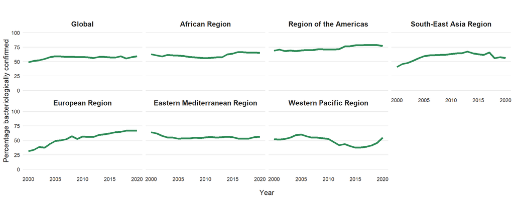

<sup>a</sup> The calculation for new and relapse pulmonary cases in years prior to 2013 is based on smear results, except for the European Region where data on confirmation by culture was also available for the period 2002-2012.

### Fig. 3.2.2 Percentage of new and relapse pulmonary TB cases with bacteriological confirmation, 2000−2020, 30 high TB burden countries

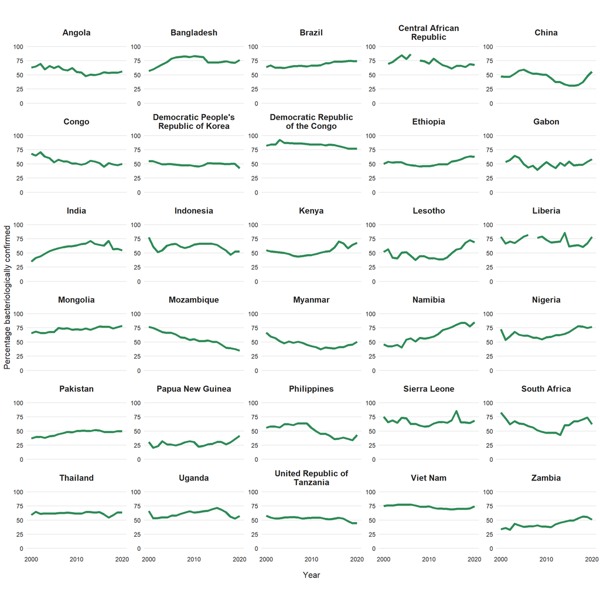

### Fig. 3.2.3 Percentage of new and relapse pulmonary TB cases with bacteriological confirmation, 2020

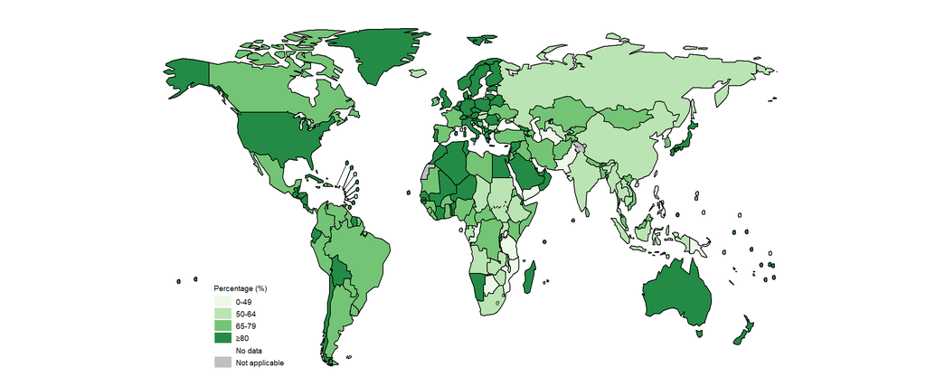

### Fig. 3.2.4 Distribution of the proportion of notified pulmonary cases that were bacteriologically confirmed in 2020, by country income group

Boxes indicate the first, second (median) and third quartiles weighted by a country’s number of pulmonary cases; vertical lines extend to the minimum and maximum values. Countries with less than 100 cases are excluded

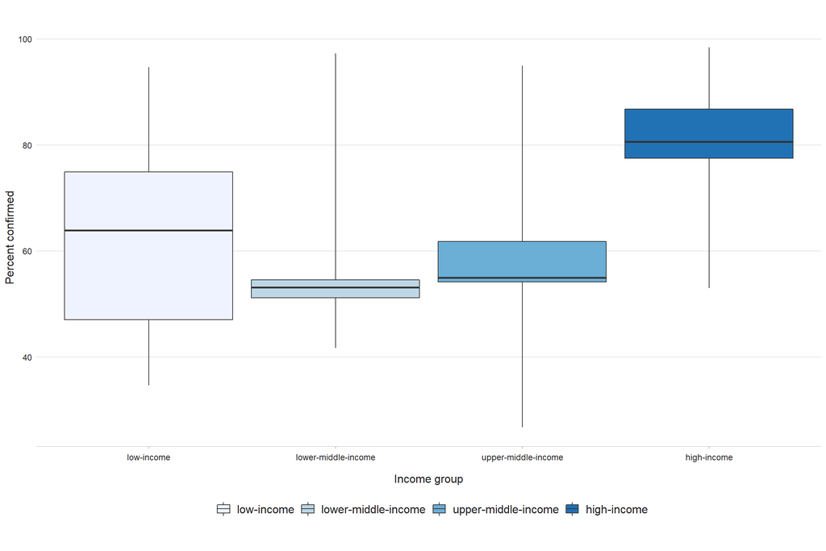

### Fig. 3.2.5 Percentage of new and relapse TB cases initially tested with a WHO-recommended rapid diagnostic test, 2020

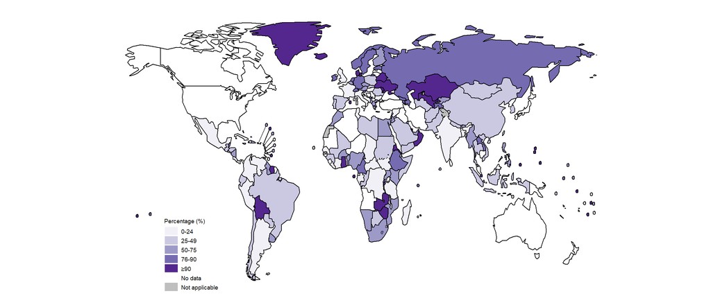

### Fig. 3.2.6 Percentage of new and relapse TB cases<sup>a</sup> with documented HIV status, 2004−2020, globally and for WHO regions<sup>b</sup>

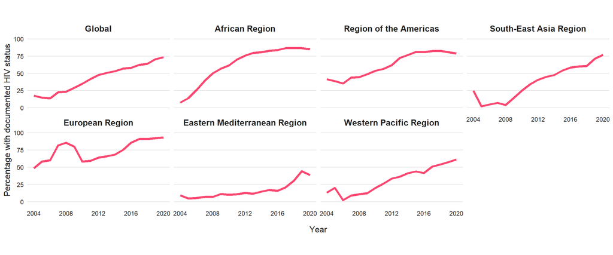

<sup>a</sup> The calculation is for all cases in years prior to 2015.  
<sup>b</sup> Countries were excluded if the number with documented HIV status was not reported to WHO.

### Fig. 3.2.7 Percentage of new and relapse TB cases with documented HIV status, 2020

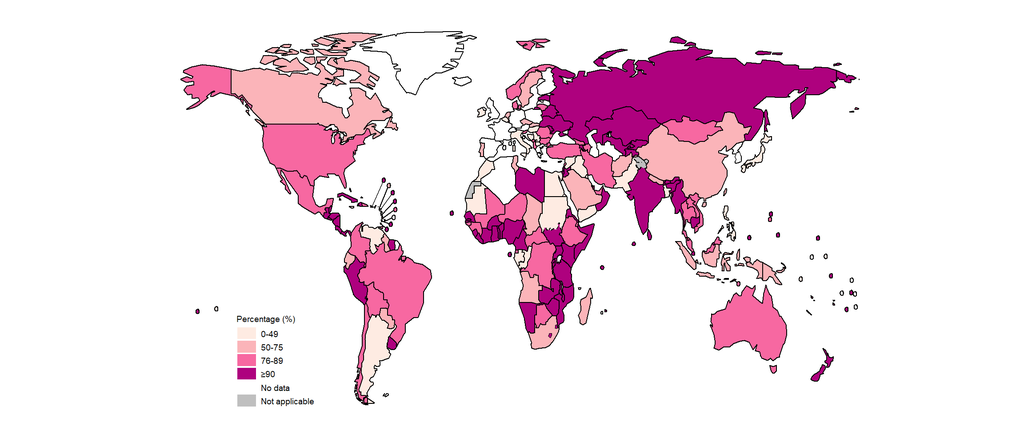

### Fig. 3.2.8 Percentage of bacteriologically confirmed TB cases tested for RR-TB<sup>a</sup>, globally and for WHO regions, 2009−2020

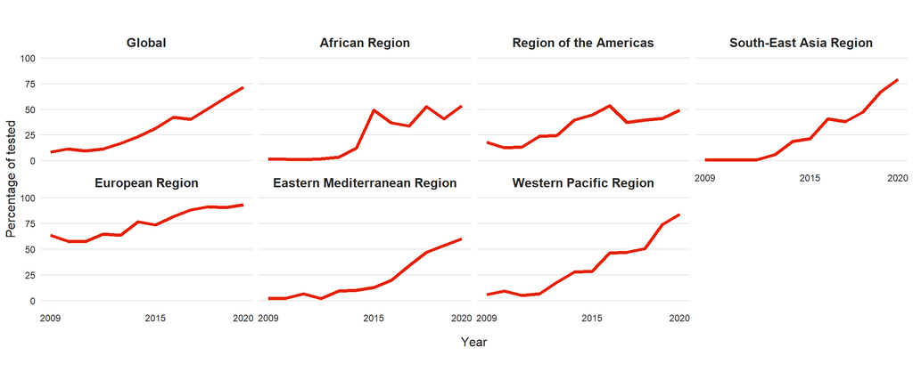

<sup>a</sup> Includes both new and previously treated cases; data for 2017 onwards are for pulmonary cases only.

### Fig. 3.2.9 Percentage of bacteriologically confirmed TB cases tested for RR-TB,<sup>a</sup> 2020

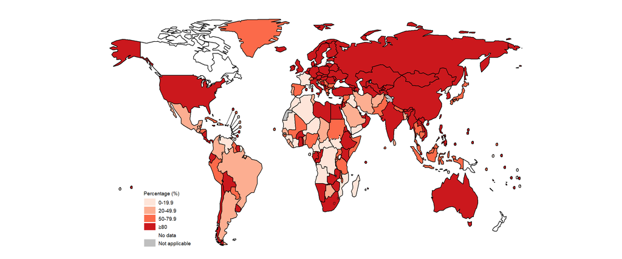

<sup>a</sup> Includes both new and previously treated cases; data are for pulmonary cases only.

### Fig. 3.2.10 Percentage of MDR/RR-TB cases tested for susceptibility to fluoroquinolones, 2020

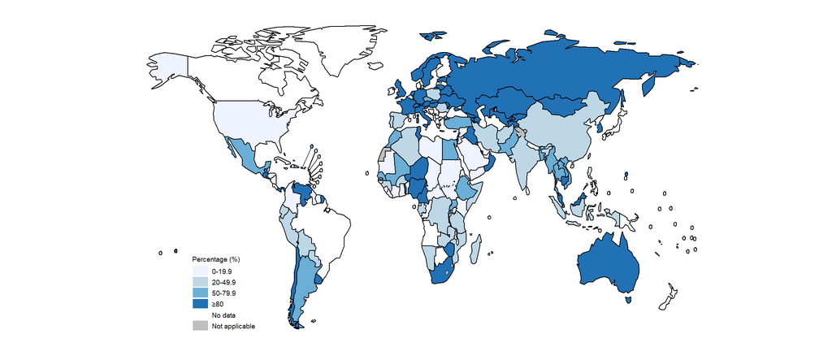

### Fig. 3.2.11 Percentage of MDR/RR-TB cases tested for susceptibility to fluoroquinolones<sup>a</sup>, globally and for WHO regions, 2015−2020

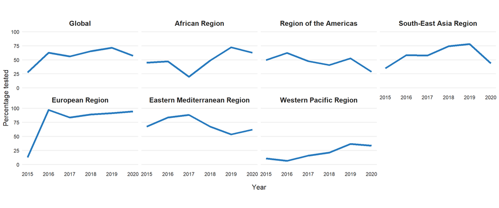

<sup>a</sup> Testing in years prior to 2019 also included susceptibility to second-line injectables.